# Juvenile snowshoe hare sizes: exploratory report

By: Daija Odom

2021-11-10

## Introduction

### 1. Overview

This report provides an exploratory overview of counts and differences in juvenile snowshoe hare (*Lepus americanus*) sizes in the Bonanza Creek Experimental Forest from 1999 - 2012. Counts were taken from 3 sampling sites (Bonanza Riparian, Bonanza Mature, and Lowland Black Spruce). Specifically, juvenile hare weights are compared by sex and site. And the relationship changes in respect to hind foot length are explored.

### 2. Data and methods

Snowshoe hare capture-recapture was conducted at 5 locales in the Tanana valley and made available by Associate Professor Knut Kielland and colleagues at the Bonanza Creek Long Term Ecological Research (LTER) Network site (Kielland et al. 2017). Following exploratory data visualization, hare weight between male and female juvenile hares are by unpaired two-sample t-tests using a significance level of ($\alpha$) of 0.05 throughout. Differences between groups are described by Cohen’s d effect size and the relationship between hind foot length and hare weight is explored by simple linear regression. All analyses are in R version 4.1.1 using RStudio version 1.4.1717.

### 3. Preliminary results

#### A. Number of juvenile hare trappings comparison

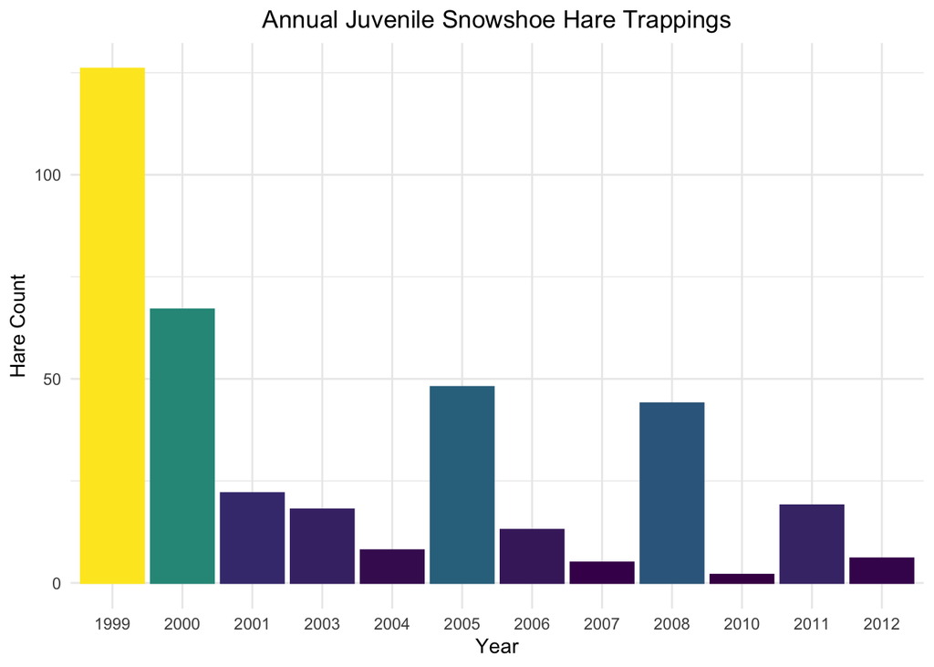

**Figure 1.** Total number of juvenile snowshoe hare trappings (male and female) annually.

The minimum number of juvenile hares trapped are 2 and the maximum number of juvenile hares trapped are 126. The mean annual number of hares trapped is 31.5 and the median is 18.5. Hare counts are highest in 1999 and overall decrease in the years thereafter with the smallest count being in 2010. To standardize the juvenile hare population in future analyses I suggest monitoring vegetation and predators in each site which affect changes in the hare densities and setting up the traps on the same days every year.

#### B. Juvenile hare weights comparison

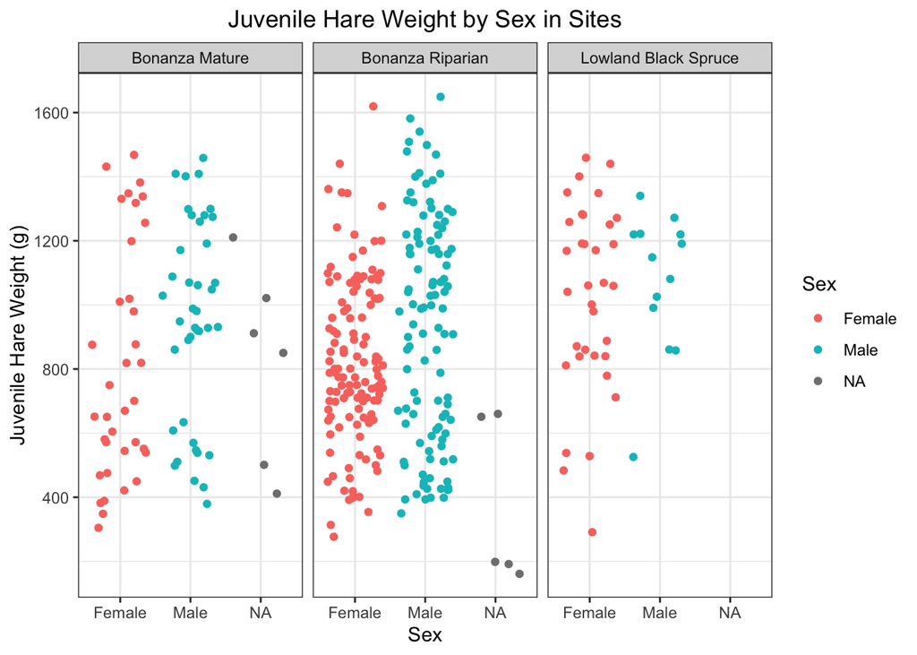

This graph shows normal distribution for both female and male juvenile snowshoe hare weight. Bonanaza Riparian appears to have the most observations for both males and females. The number of observations could involve the actual population size at each site due to study efforts.

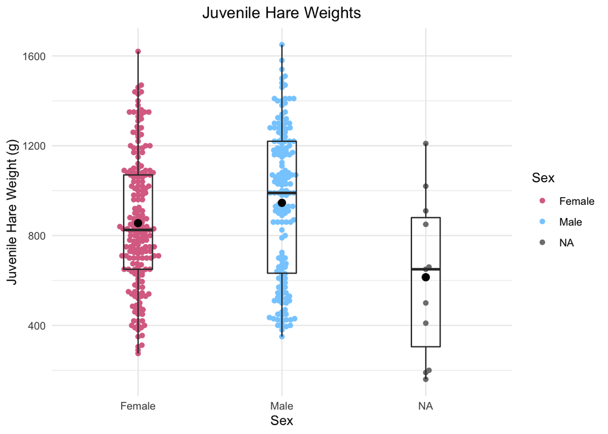

**Figure 4.** Hare weight observations (g) for juvenile female and male snowshoe hares. Violet-red (female), sky blue (male), and gray (NA) points indicate individual observations for juvenile hare weights (grams). Box endpoints indicate the 25th and 75th percentile values; the gray line and black point within the box indicate the median and mean value for each species, respectively. Data: Kielland et al. (2017).

Visualizations show juvenile snowshoe hare weight by sex (male and female) with summary statistics (mean and median).

#### C. Juvenile weight comparison (male and female snowshoe hares)

There is an actual difference of 90.47 (g) in means. Mean hare weights for female juvenile snowshoe hares (855.39 g $\pm$ 292.25 g; mean $\pm$ 1 standard deviation, n = 200) were only slightly smaller than those of male juvenile snowshoe hares (945.86 $\pm$ 333.22 cm; mean $\pm$ 1 standard deviation n = 163), a difference of just over 10.05%. The difference in means is statistically significant (Welch’s two-sample t-test: t(325.02) = 2.71, p = 0.007). The effect size was small (Cohen’s *d* = 0.2904674).

#### D. Relationship between juvenile weight and hind foot length

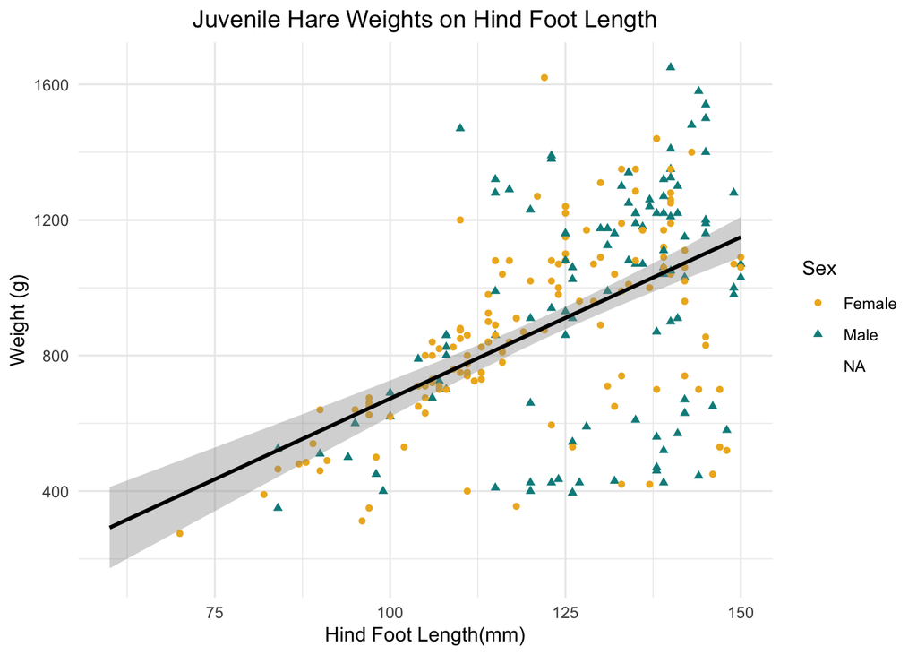

As a starting point, the relationship between hare weight and hind foot length was explored across the snowshoe hares (i.e. ignoring site and sex).

## Summary

The exploratory data analysis reveals the following initial findings:

- There are inconsistencies within the overall trapping observations of the data with observations missing in 2002 and 2009.
- On average, juvenile snowshoe hare females have smaller body weights than juvenile snowshoe hare males.
- The relationship between hind foot length (mm) and body mass (g) does not appear to be best representend by a simple linear regression. The p-value tells you that this is significant, but the models are not right.In simple linear regression 30 % of the variance is based on body mass. Heteroscedastic because the spread of the residuals change about the model in a non-random way.

Next steps:

- Compare hind foot lengths statistically (one-way ANOVA), including snowshoe hare sex as a covariate.
- Multiple linear regression to understand the relationship between sex, site, body mass, and hind foot length.
- Analysis of nesting pairs to explore size correlation.

## Citations

Kielland, K., F.S. Chapin, R.W. Ruess, and Bonanza Creek LTER. 2017. Snowshoe hare physical data in Bonanza Creek Experimental Forest: 1999-Present ver 22. Environmental Data Initiative. https://doi.org/10.6073/pasta/03dce4856d79b91557d8e6ce2cbcdc14